# rbacon

# 1 Introduction

This document is the maintained and authoritative manual for the Bacon package. Bacon is an age-depth modelling tool which divides a sediment core up into equally-sized sections of (by default) 5 cm thickness, and assumes a linear accumulation within each section. Accumulation rates can change between the sections, and this variability is constrained by prior information (see below). Bacon can use radiocarbon dates (calibrating them as it runs) or dates that are already on the calendar scale (such as pollen markers).

This manual supersedes earlier pre‑2019 versions hosted at chrono.qub.ac.uk/blaauw/, which are obsolete and unmaintained.

# 2 Installation and loading

Bacon works through `R` (or Rstudio), and requires a recent version of `R` (at least 4.0.0). The first time you are using Bacon on your computer, you will have to install its `R` package (named `rbacon`, all lowercase), by typing within the terminal of `R`:

```r
install.packages('rbacon')
```

To use rbacon, first the package has to be loaded (this will also load its companion packages `rice` and `rintcal`):

```r
library(rbacon)
```

# 3 Running rbacon

The package comes with two pre-loaded datasets, MSB2K and RLGH3. Start by running the default core, MSB2K. Note `R`‘s comments about where the files are going to be placed, as we will need this information later. Press ’y’ and/or Enter to accept any suggestions.

```r
Bacon()
```

Bacon will calibrate any C-14 dates, do the MCMC run, calculate age ranges, produce graphs and provide information about the posterior distributions and the age-depth model’s confidence ranges. The output graph, below, contains a number of panels containing important information (so please don’t cut them out for your publications):

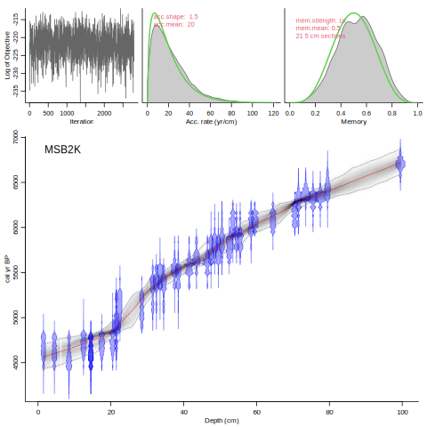

Bacon output plot

Besides the graph, Bacon also produces files containing age estimates (95% ranges and the mean) for each depth (by default every cm from the top to the bottom core depth). This file can be found in the core’s folder (see ‘6 Folders and Files’). Also reported are how well the MCMC run went, and summaries of the confidence ranges, the overlap between the dates and the age-depth model, and a comparison of the prior and posterior values for the accumulation rate and memory (including a ‘learning ratio’). A file ending in `_summary.txt`, containing the above information, is written to the core’s folder.

To see all options and settings, ask for help:

```r
?Bacon
```

and to see all options and settings for the age-model plot, type:

```r
?agedepth
```

# 4 Citations and versions

rbacon is open-source software; you are free to use, copy, distribute and modify it, but please do read this tutorial, the help functions and accompanying paper before using the program. This software is distributed under the terms of the GNU General Public Licence. rbacon does not come with any warranty and the authors do not assume any responsibility for the usefulness of any portion of this program. *Do cite this program when modifying or using it, including its version, Blaauw and Christen (2011)[^1], applied settings and calibration curve(s) used.*

Parts of this software remain under construction. Details such as the default settings and behaviour could change between versions, so please check this manual for the latest information. You are most welcome to report bugs, ideas and missing features to Maarten maarten.blaauw@qub.ac.uk, Marco aquino@cimat.mx or Andrés jac@cimat.mx.

# 5 Choosing priors

## 5.1 Accumulation rate

Another core that comes with rbacon is RLGH3[^2]. This core has a lower dating density than MSB2K and has a section where there appear to be outlying dates (or in other words, some of the dates don’t seem to agree with other nearby dates). Since initial checks indicate a slower accumulation rate (or rather, sedimentation time) than rbacon’s default of 20 yr/cm, rbacon will ask if the prior should be changed to 50 yr/cm. For now, respond with `n` or `Enter`, so that the default, non-adapted settings will be used.

```r
Bacon('RLGH3')
```

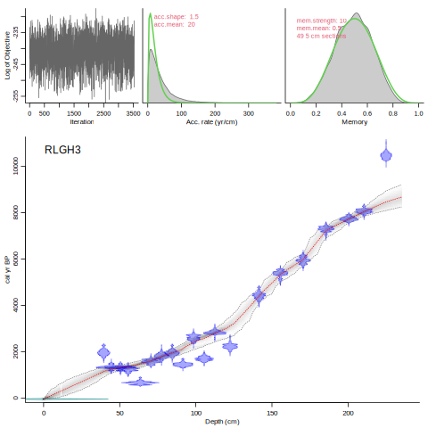

age-depth model of RLGH3 using the default settings

Note that with the default settings, the age-model bypasses some of the younger dates between 130 and 60 cm core depth, since the older dates within that core section seem to fit better with the model and the dates further downcore and higher up the core. On top of this, the model bypasses the bottom date, because if the age-model were to go through this date, it would require large-scale changes in sedimentation times which seem to be prohibited by the default settings for the prior information. So let’s run the model again, this time accepting the suggested value of 50 yr/cm for the accumulation rate `acc.mean` (type `y` and press `Enter`):

```r
Bacon('RLGH3')
```

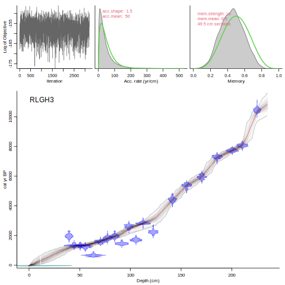

age-depth model of RLGH3 using suggested settings

With the adapted prior for the accumulation rate, now the lowermost date *is* taken into account. Now, what if someone you trusted told you that they had some very strong information from other nearby lakes that sedimentation times are very likely to be 50 yr/cm? Then we can set the prior to be much more restrictive/stronger than the default - we let the green curve peak higher (larger acc.shape value) so that the accumulation rates are ‘forced’ to values around 50 yr/cm:

```r
Bacon('RLGH3', acc.mean=50, acc.shape=100)
```

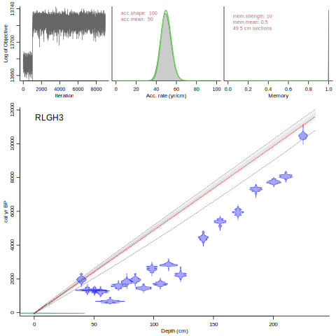

age-depth model of RLGH3 using a much stronger accumulation rate prior

Bacon did what it was told to do. The posterior accumulation rates fit very well with the prior’s mean of 50 yr/cm. The age-depth model itself however is very straight and isn’t very realistic, and most of the dates don’t fit with the model. Note also the top-left panel which shows the MCMC run; the first thousand or so iterations are still sub-optimal and should really be removed using the `scissors` function. In all, not a good age-depth model, and it’s probably a good idea to talk to your expert again, or find someone else with more realistic prior information.

When comparing the prior (green) and posterior (grey) distributions of the accumulation rate and the memory, it can be helpful to consider that the Bayesian approach aims to combine prior information with new data in order to ‘learn’ about the process, in other words to update its information about the parameters involved. The default priors were chosen to be sufficiently broad to allow the data to inform us about the accumulation rate and its variability.